# Airline Passengers Satisfaction Prediction

### By Ludmila Emília Mucavele

## Content

- Dataset Introduction
- Data Gathering and Wrangling
- Pre-Processing
- Model Evaluation
- Satisfaction Prediction

## Dataset Introduction

The dataset contains Customer satisfaction scores from 120,000+ airline passengers, including additional information about each passenger, their flight, and type of travel, as well as their evaluation of different factors like cleanliness, comfort, service, and overall experience.

The dataset can be found [here](https://www.kaggle.com/datasets/mysarahmadbhat/airline-passenger-satisfaction).

The aim of the project is to develop a predictive system for passenger satisfaction based on passengers' flights information.

More details are shown in the dictionary below.

- **ID:** Unique passenger identifier
- **Gender:** Gender of the passenger (Female/Male)
- **Age:** Age of the passenger
- **Customer Type:** Type of airline customer (First-time/Returning)
- **Type of Travel:** Purpose of the flight (Business/Personal)
- **Class Travel:** class in the airplane for the passenger seat
- **Flight Distance:** Flight distance in miles
- **Departure Delay:** Flight departure delay in minutes
- **Arrival Delay:** Flight arrival delay in minutes
- **Departure and Arrival Time Convenience:** Satisfaction level with the convenience of the flight departure and arrival times from 1 (lowest) to 5 (highest) - 0 means "not applicable"
- **Ease of Online Booking:** Satisfaction level with the online booking experience from 1 (lowest) to 5 (highest) - 0 means "not applicable"
- **Check-in Service:** Satisfaction level with the check-in service from 1 (lowest) to 5 (highest) - 0 means "not applicable"
- **Online Boarding:** Satisfaction level with the online boarding experience from 1 (lowest) to 5 (highest) - 0 means "not applicable"
- **Gate Location:** Satisfaction level with the gate location in the airport from 1 (lowest) to 5 (highest) - 0 means "not applicable"
- **On-board Service:** Satisfaction level with the on-boarding service in the airport from 1 (lowest) to 5 (highest) - 0 means "not applicable"
- **Seat Comfort:** Satisfaction level with the comfort of the airplane seat from 1 (lowest) to 5 (highest) - 0 means "not applicable"
- **Leg Room Service:** Satisfaction level with the leg room of the airplane seat from 1 (lowest) to 5 (highest) - 0 means "not applicable"
- **Cleanliness:** Satisfaction level with the cleanliness of the airplane from 1 (lowest) to 5 (highest) - 0 means "not applicable"
- **Food and Drink:** Satisfaction level with the food and drinks on the airplane from 1 (lowest) to 5 (highest) - 0 means "not applicable"
- **In-flight Service:** Satisfaction level with the in-flight service from 1 (lowest) to 5 (highest) - 0 means "not applicable"
- **In-flight Wifi Service:** Satisfaction level with the in-flight Wifi service from 1 (lowest) to 5 (highest) - 0 means "not applicable"
- **In-flight Entertainment:** Satisfaction level with the in-flight entertainment from 1 (lowest) to 5 (highest) - 0 means "not applicable"
- **Baggage Handling:** Satisfaction level with the baggage handling from the airline from 1 (lowest) to 5 (highest) - 0 means "not applicable"
- **Satisfaction:** Overall satisfaction level with the airline (Satisfied/Neutral or unsatisfied)

#### Packages

```python
import pandas as pd
import numpy as np
import matplotlib.pyplot as plt
import seaborn as sns
import sklearn
%matplotlib inline
np.random.seed(0)
```

## Data Gathering and Cleaning

Let's start with collecting and cleaning the data for training and testing in the model.

```python
df = pd.read_csv('airline_passenger_satisfaction.csv')
df.head()
```

|  | ID | Gender | Age | Customer Type | Type of Travel | Class | Flight Distance | Departure Delay | Arrival Delay | Departure and Arrival Time Convenience | ... | On-board Service | Seat Comfort | Leg Room Service | Cleanliness | Food and Drink | In-flight Service | In-flight Wifi Service | In-flight Entertainment | Baggage Handling | Satisfaction |
| --- | --- | --- | --- | --- | --- | --- | --- | --- | --- | --- | --- | --- | --- | --- | --- | --- | --- | --- | --- | --- | --- |
| 0 | 1 | Male | 48 | First-time | Business | Business | 821 | 2 | 5.0 | 3 | ... | 3 | 5 | 2 | 5 | 5 | 5 | 3 | 5 | 5 | Neutral or Dissatisfied |
| 1 | 2 | Female | 35 | Returning | Business | Business | 821 | 26 | 39.0 | 2 | ... | 5 | 4 | 5 | 5 | 3 | 5 | 2 | 5 | 5 | Satisfied |
| 2 | 3 | Male | 41 | Returning | Business | Business | 853 | 0 | 0.0 | 4 | ... | 3 | 5 | 3 | 5 | 5 | 3 | 4 | 3 | 3 | Satisfied |
| 3 | 4 | Male | 50 | Returning | Business | Business | 1905 | 0 | 0.0 | 2 | ... | 5 | 5 | 5 | 4 | 4 | 5 | 2 | 5 | 5 | Satisfied |
| 4 | 5 | Female | 49 | Returning | Business | Business | 3470 | 0 | 1.0 | 3 | ... | 3 | 4 | 4 | 5 | 4 | 3 | 3 | 3 | 3 | Satisfied |

5 rows × 24 columns

```python
df.info()
```

```
<class 'pandas.core.frame.DataFrame'>
RangeIndex: 129880 entries, 0 to 129879
Data columns (total 24 columns):
 #   Column                                  Non-Null Count   Dtype
---  ------                                  --------------   -----
 0   ID                                      129880 non-null  int64
 1   Gender                                  129880 non-null  object
 2   Age                                     129880 non-null  int64
 3   Customer Type                           129880 non-null  object
 4   Type of Travel                          129880 non-null  object
 5   Class                                   129880 non-null  object
 6   Flight Distance                         129880 non-null  int64
 7   Departure Delay                         129880 non-null  int64
 8   Arrival Delay                           129487 non-null  float64
 9   Departure and Arrival Time Convenience  129880 non-null  int64
```

[output cut: 16 more lines]

```python
df.describe()
```

|  | ID | Age | Flight Distance | Departure Delay | Arrival Delay | Departure and Arrival Time Convenience | Ease of Online Booking | Check-in Service | Online Boarding | Gate Location | On-board Service | Seat Comfort | Leg Room Service | Cleanliness | Food and Drink | In-flight Service | In-flight Wifi Service | In-flight Entertainment | Baggage Handling |
| --- | --- | --- | --- | --- | --- | --- | --- | --- | --- | --- | --- | --- | --- | --- | --- | --- | --- | --- | --- |
| count | 129880.000000 | 129880.000000 | 129880.000000 | 129880.000000 | 129487.000000 | 129880.000000 | 129880.000000 | 129880.000000 | 129880.000000 | 129880.000000 | 129880.000000 | 129880.000000 | 129880.000000 | 129880.000000 | 129880.000000 | 129880.000000 | 129880.000000 | 129880.000000 | 129880.000000 |
| mean | 64940.500000 | 39.427957 | 1190.316392 | 14.713713 | 15.091129 | 3.057599 | 2.756876 | 3.306267 | 3.252633 | 2.976925 | 3.383023 | 3.441361 | 3.350878 | 3.286326 | 3.204774 | 3.642193 | 2.728696 | 3.358077 | 3.632114 |
| std | 37493.270818 | 15.119360 | 997.452477 | 38.071126 | 38.465650 | 1.526741 | 1.401740 | 1.266185 | 1.350719 | 1.278520 | 1.287099 | 1.319289 | 1.316252 | 1.313682 | 1.329933 | 1.176669 | 1.329340 | 1.334049 | 1.180025 |
| min | 1.000000 | 7.000000 | 31.000000 | 0.000000 | 0.000000 | 0.000000 | 0.000000 | 0.000000 | 0.000000 | 0.000000 | 0.000000 | 0.000000 | 0.000000 | 0.000000 | 0.000000 | 0.000000 | 0.000000 | 0.000000 | 1.000000 |
| 25% | 32470.750000 | 27.000000 | 414.000000 | 0.000000 | 0.000000 | 2.000000 | 2.000000 | 3.000000 | 2.000000 | 2.000000 | 2.000000 | 2.000000 | 2.000000 | 2.000000 | 2.000000 | 3.000000 | 2.000000 | 2.000000 | 3.000000 |
| 50% | 64940.500000 | 40.000000 | 844.000000 | 0.000000 | 0.000000 | 3.000000 | 3.000000 | 3.000000 | 3.000000 | 3.000000 | 4.000000 | 4.000000 | 4.000000 | 3.000000 | 3.000000 | 4.000000 | 3.000000 | 4.000000 | 4.000000 |
| 75% | 97410.250000 | 51.000000 | 1744.000000 | 12.000000 | 13.000000 | 4.000000 | 4.000000 | 4.000000 | 4.000000 | 4.000000 | 4.000000 | 5.000000 | 4.000000 | 4.000000 | 4.000000 | 5.000000 | 4.000000 | 4.000000 | 5.000000 |
| max | 129880.000000 | 85.000000 | 4983.000000 | 1592.000000 | 1584.000000 | 5.000000 | 5.000000 | 5.000000 | 5.000000 | 5.000000 | 5.000000 | 5.000000 | 5.000000 | 5.000000 | 5.000000 | 5.000000 | 5.000000 | 5.000000 | 5.000000 |

```python
# Check for null values in Arrival Delay column
df[df['Arrival Delay'].isna()].head()
```

|  | ID | Gender | Age | Customer Type | Type of Travel | Class | Flight Distance | Departure Delay | Arrival Delay | Departure and Arrival Time Convenience | ... | On-board Service | Seat Comfort | Leg Room Service | Cleanliness | Food and Drink | In-flight Service | In-flight Wifi Service | In-flight Entertainment | Baggage Handling | Satisfaction |
| --- | --- | --- | --- | --- | --- | --- | --- | --- | --- | --- | --- | --- | --- | --- | --- | --- | --- | --- | --- | --- | --- |
| 246 | 247 | Male | 11 | Returning | Business | Business | 719 | 38 | NaN | 1 | ... | 4 | 4 | 3 | 4 | 4 | 3 | 4 | 4 | 4 | Neutral or Dissatisfied |
| 883 | 884 | Male | 39 | Returning | Business | Business | 396 | 0 | NaN | 3 | ... | 3 | 4 | 3 | 3 | 3 | 3 | 3 | 3 | 3 | Satisfied |
| 1965 | 1966 | Male | 36 | Returning | Business | Economy | 383 | 2 | NaN | 4 | ... | 5 | 2 | 2 | 2 | 2 | 2 | 2 | 2 | 3 | Satisfied |
| 2407 | 2408 | Female | 55 | Returning | Business | Business | 2904 | 58 | NaN | 5 | ... | 4 | 3 | 4 | 4 | 5 | 4 | 4 | 4 | 4 | Neutral or Dissatisfied |
| 2448 | 2449 | Male | 21 | Returning | Personal | Economy Plus | 767 | 5 | NaN | 3 | ... | 4 | 1 | 2 | 1 | 1 | 2 | 1 | 1 | 1 | Neutral or Dissatisfied |

5 rows × 24 columns

```python
# Fix null values in Arrival Delay column
df.loc[df['Arrival Delay'].isna(), 'Arrival Delay'] = 0
df['Arrival Delay'].astype(int)
assert df['Arrival Delay'].isna().sum() == 0
```

```python
df.duplicated().sum()
```

```
0
```

```python
df.nunique()
```

```
ID                                        129880
Gender                                         2
Age                                           75
Customer Type                                  2
Type of Travel                                 2
Class                                          3
Flight Distance                             3821
Departure Delay                              466
Arrival Delay                                472
Departure and Arrival Time Convenience         6
Ease of Online Booking                         6
Check-in Service                               6
Online Boarding                                6
Gate Location                                  6
On-board Service                               6
Seat Comfort                                   6
Leg Room Service                               6
Cleanliness                                    6
Food and Drink                                 6
In-flight Service                              6
In-flight Wifi Service                         6
In-flight Entertainment                        6
Baggage Handling                               5
Satisfaction                                   2
dtype: int64
```

## Pre-Processing

```python
# Turn Satisfaction column to numeric categorical feature
dict = ({'Neutral or Dissatisfied' : 0, 'Satisfied' : 1})
df.Satisfaction = df.Satisfaction.map(dict)
df.head()
```

|  | ID | Gender | Age | Customer Type | Type of Travel | Class | Flight Distance | Departure Delay | Arrival Delay | Departure and Arrival Time Convenience | ... | On-board Service | Seat Comfort | Leg Room Service | Cleanliness | Food and Drink | In-flight Service | In-flight Wifi Service | In-flight Entertainment | Baggage Handling | Satisfaction |
| --- | --- | --- | --- | --- | --- | --- | --- | --- | --- | --- | --- | --- | --- | --- | --- | --- | --- | --- | --- | --- | --- |
| 0 | 1 | Male | 48 | First-time | Business | Business | 821 | 2 | 5.0 | 3 | ... | 3 | 5 | 2 | 5 | 5 | 5 | 3 | 5 | 5 | 0 |
| 1 | 2 | Female | 35 | Returning | Business | Business | 821 | 26 | 39.0 | 2 | ... | 5 | 4 | 5 | 5 | 3 | 5 | 2 | 5 | 5 | 1 |
| 2 | 3 | Male | 41 | Returning | Business | Business | 853 | 0 | 0.0 | 4 | ... | 3 | 5 | 3 | 5 | 5 | 3 | 4 | 3 | 3 | 1 |
| 3 | 4 | Male | 50 | Returning | Business | Business | 1905 | 0 | 0.0 | 2 | ... | 5 | 5 | 5 | 4 | 4 | 5 | 2 | 5 | 5 | 1 |
| 4 | 5 | Female | 49 | Returning | Business | Business | 3470 | 0 | 1.0 | 3 | ... | 3 | 4 | 4 | 5 | 4 | 3 | 3 | 3 | 3 | 1 |

5 rows × 24 columns

```python
# Transforming non numeric categorical features
df = pd.get_dummies(data = df, columns = ['Gender', 'Customer Type', 'Type of Travel',
                                         'Class'], drop_first=True)
df.head()
```

|  | ID | Age | Flight Distance | Departure Delay | Arrival Delay | Departure and Arrival Time Convenience | Ease of Online Booking | Check-in Service | Online Boarding | Gate Location | ... | In-flight Service | In-flight Wifi Service | In-flight Entertainment | Baggage Handling | Satisfaction | Gender_Male | Customer Type_Returning | Type of Travel_Personal | Class_Economy | Class_Economy Plus |
| --- | --- | --- | --- | --- | --- | --- | --- | --- | --- | --- | --- | --- | --- | --- | --- | --- | --- | --- | --- | --- | --- |
| 0 | 1 | 48 | 821 | 2 | 5.0 | 3 | 3 | 4 | 3 | 3 | ... | 5 | 3 | 5 | 5 | 0 | 1 | 0 | 0 | 0 | 0 |
| 1 | 2 | 35 | 821 | 26 | 39.0 | 2 | 2 | 3 | 5 | 2 | ... | 5 | 2 | 5 | 5 | 1 | 0 | 1 | 0 | 0 | 0 |
| 2 | 3 | 41 | 853 | 0 | 0.0 | 4 | 4 | 4 | 5 | 4 | ... | 3 | 4 | 3 | 3 | 1 | 1 | 1 | 0 | 0 | 0 |
| 3 | 4 | 50 | 1905 | 0 | 0.0 | 2 | 2 | 3 | 4 | 2 | ... | 5 | 2 | 5 | 5 | 1 | 1 | 1 | 0 | 0 | 0 |
| 4 | 5 | 49 | 3470 | 0 | 1.0 | 3 | 3 | 3 | 5 | 3 | ... | 3 | 3 | 3 | 3 | 1 | 0 | 1 | 0 | 0 | 0 |

5 rows × 25 columns

Let's have a look at the correlation of the data features and the target.

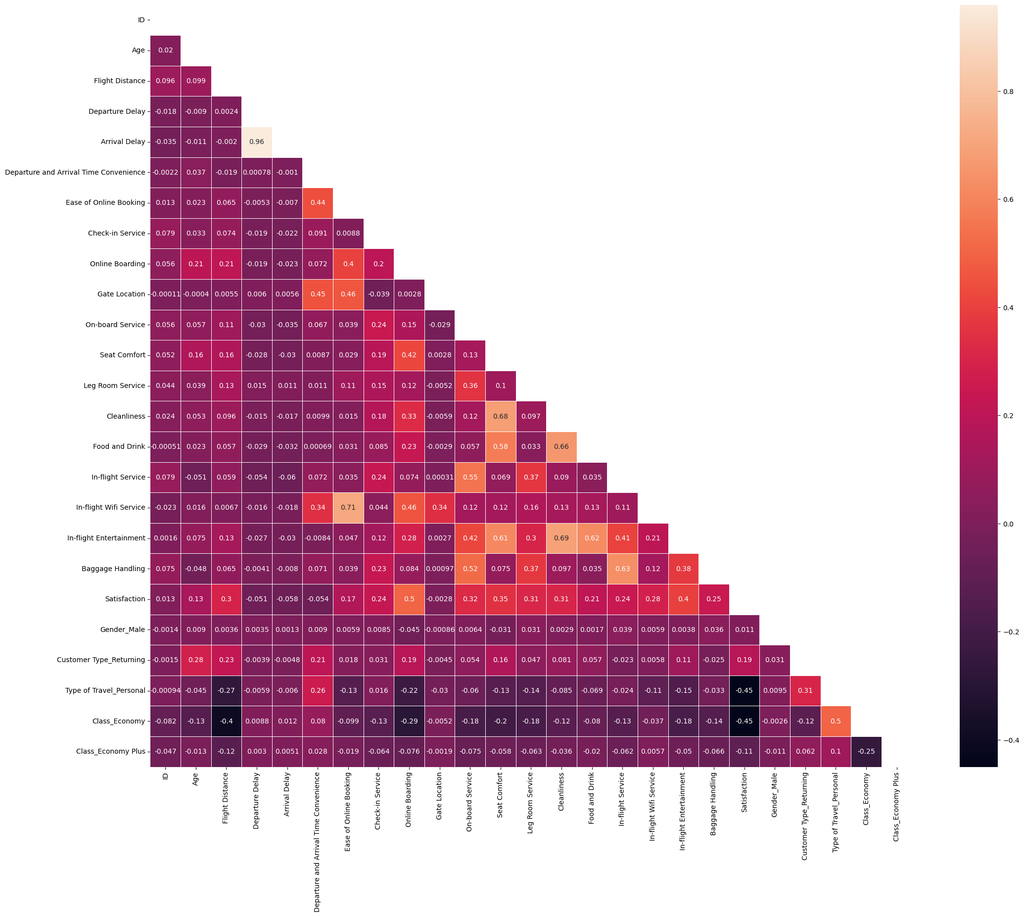

```python
plt.figure(figsize = (25, 20))

# Generate a mask for the upper triangle
mask = np.zeros_like(df.corr())
mask[np.triu_indices_from(mask)] = True
# plot the Heat map
sns.heatmap(df.corr(),  annot=True, mask = mask, square=True, linewidths=.5);
```

**Note:** Arrival Delay feature feauture will be dropped to avoiding multicorrelation problem, once there is a significant correlation between Departure Delay and Arrival Delay.

```python
# Drop unnecessary features
df.drop(['ID', 'Age', 'Flight Distance'], axis = 1, inplace = True)

# Drop Arrival Delay feature for avoiding multicorrelation problem
df.drop(['Arrival Delay'], axis = 1, inplace = True)

df
```

|  | Departure Delay | Departure and Arrival Time Convenience | Ease of Online Booking | Check-in Service | Online Boarding | Gate Location | On-board Service | Seat Comfort | Leg Room Service | Cleanliness | ... | In-flight Service | In-flight Wifi Service | In-flight Entertainment | Baggage Handling | Satisfaction | Gender_Male | Customer Type_Returning | Type of Travel_Personal | Class_Economy | Class_Economy Plus |
| --- | --- | --- | --- | --- | --- | --- | --- | --- | --- | --- | --- | --- | --- | --- | --- | --- | --- | --- | --- | --- | --- |
| 0 | 2 | 3 | 3 | 4 | 3 | 3 | 3 | 5 | 2 | 5 | ... | 5 | 3 | 5 | 5 | 0 | 1 | 0 | 0 | 0 | 0 |
| 1 | 26 | 2 | 2 | 3 | 5 | 2 | 5 | 4 | 5 | 5 | ... | 5 | 2 | 5 | 5 | 1 | 0 | 1 | 0 | 0 | 0 |
| 2 | 0 | 4 | 4 | 4 | 5 | 4 | 3 | 5 | 3 | 5 | ... | 3 | 4 | 3 | 3 | 1 | 1 | 1 | 0 | 0 | 0 |
| 3 | 0 | 2 | 2 | 3 | 4 | 2 | 5 | 5 | 5 | 4 | ... | 5 | 2 | 5 | 5 | 1 | 1 | 1 | 0 | 0 | 0 |
| 4 | 0 | 3 | 3 | 3 | 5 | 3 | 3 | 4 | 4 | 5 | ... | 3 | 3 | 3 | 3 | 1 | 0 | 1 | 0 | 0 | 0 |
| ... | ... | ... | ... | ... | ... | ... | ... | ... | ... | ... | ... | ... | ... | ... | ... | ... | ... | ... | ... | ... | ... |
| 129875 | 2 | 4 | 4 | 4 | 4 | 2 | 5 | 1 | 4 | 4 | ... | 5 | 4 | 4 | 4 | 0 | 1 | 1 | 1 | 0 | 1 |
| 129876 | 0 | 5 | 3 | 5 | 3 | 4 | 5 | 2 | 5 | 2 | ... | 4 | 3 | 2 | 5 | 0 | 1 | 1 | 1 | 0 | 1 |
| 129877 | 6 | 5 | 2 | 4 | 2 | 1 | 3 | 3 | 4 | 3 | ... | 4 | 2 | 3 | 5 | 0 | 1 | 1 | 1 | 0 | 1 |
| 129878 | 31 | 4 | 4 | 3 | 4 | 1 | 4 | 4 | 5 | 3 | ... | 4 | 5 | 3 | 5 | 1 | 1 | 1 | 1 | 0 | 1 |
| 129879 | 0 | 1 | 3 | 4 | 3 | 2 | 4 | 2 | 4 | 2 | ... | 2 | 3 | 2 | 1 | 0 | 0 | 1 | 1 | 0 | 1 |

129880 rows × 21 columns

```python
columns = list(df.columns)
for i in columns:
    df[i] = pd.to_numeric(df[i], errors = 'coerce')
df
```

|  | Departure Delay | Departure and Arrival Time Convenience | Ease of Online Booking | Check-in Service | Online Boarding | Gate Location | On-board Service | Seat Comfort | Leg Room Service | Cleanliness | ... | In-flight Service | In-flight Wifi Service | In-flight Entertainment | Baggage Handling | Satisfaction | Gender_Male | Customer Type_Returning | Type of Travel_Personal | Class_Economy | Class_Economy Plus |
| --- | --- | --- | --- | --- | --- | --- | --- | --- | --- | --- | --- | --- | --- | --- | --- | --- | --- | --- | --- | --- | --- |
| 0 | 2 | 3 | 3 | 4 | 3 | 3 | 3 | 5 | 2 | 5 | ... | 5 | 3 | 5 | 5 | 0 | 1 | 0 | 0 | 0 | 0 |
| 1 | 26 | 2 | 2 | 3 | 5 | 2 | 5 | 4 | 5 | 5 | ... | 5 | 2 | 5 | 5 | 1 | 0 | 1 | 0 | 0 | 0 |
| 2 | 0 | 4 | 4 | 4 | 5 | 4 | 3 | 5 | 3 | 5 | ... | 3 | 4 | 3 | 3 | 1 | 1 | 1 | 0 | 0 | 0 |
| 3 | 0 | 2 | 2 | 3 | 4 | 2 | 5 | 5 | 5 | 4 | ... | 5 | 2 | 5 | 5 | 1 | 1 | 1 | 0 | 0 | 0 |
| 4 | 0 | 3 | 3 | 3 | 5 | 3 | 3 | 4 | 4 | 5 | ... | 3 | 3 | 3 | 3 | 1 | 0 | 1 | 0 | 0 | 0 |
| ... | ... | ... | ... | ... | ... | ... | ... | ... | ... | ... | ... | ... | ... | ... | ... | ... | ... | ... | ... | ... | ... |
| 129875 | 2 | 4 | 4 | 4 | 4 | 2 | 5 | 1 | 4 | 4 | ... | 5 | 4 | 4 | 4 | 0 | 1 | 1 | 1 | 0 | 1 |
| 129876 | 0 | 5 | 3 | 5 | 3 | 4 | 5 | 2 | 5 | 2 | ... | 4 | 3 | 2 | 5 | 0 | 1 | 1 | 1 | 0 | 1 |
| 129877 | 6 | 5 | 2 | 4 | 2 | 1 | 3 | 3 | 4 | 3 | ... | 4 | 2 | 3 | 5 | 0 | 1 | 1 | 1 | 0 | 1 |
| 129878 | 31 | 4 | 4 | 3 | 4 | 1 | 4 | 4 | 5 | 3 | ... | 4 | 5 | 3 | 5 | 1 | 1 | 1 | 1 | 0 | 1 |
| 129879 | 0 | 1 | 3 | 4 | 3 | 2 | 4 | 2 | 4 | 2 | ... | 2 | 3 | 2 | 1 | 0 | 0 | 1 | 1 | 0 | 1 |

129880 rows × 21 columns

```python
# creating predictor and target dataset
x = df.drop('Satisfaction', axis = 1)
y = pd.DataFrame(df['Satisfaction'])
print('Predictor features: '  + str(list(x.columns)))
print('Target feature: ' + str(list(y.columns)))
```

```
Predictor features: ['Departure Delay', 'Departure and Arrival Time Convenience', 'Ease of Online Booking', 'Check-in Service', 'Online Boarding', 'Gate Location', 'On-board Service', 'Seat Comfort', 'Leg Room Service', 'Cleanliness', 'Food and Drink', 'In-flight Service', 'In-flight Wifi Service', …
Target feature: ['Satisfaction']
```

Let's split it into train and test data for the model.

```python
from sklearn.model_selection import train_test_split

x_train, x_test, y_train, y_test = train_test_split(x, y, test_size = 0.2, shuffle = True, random_state = 0)
y_train, y_test = np.ravel(y_train), np.ravel(y_test)
print(x_train.shape)
print(x_test.shape)
print(y_train.shape)
print(y_test.shape)

#y_train, y_test = y_train.values.flatten(), y_test.values.flatten()
```

```
(103904, 20)
(25976, 20)
(103904,)
(25976,)
```

Data preprocessed and splitted, let's move to the model selection and comparison.

## Model Evaluation

```python
from sklearn.metrics import accuracy_score
from sklearn.linear_model import LogisticRegression
from sklearn.neighbors import KNeighborsClassifier
from sklearn.tree import DecisionTreeClassifier
from sklearn.ensemble import RandomForestClassifier
from sklearn.metrics import accuracy_score
import warnings
warnings.filterwarnings("ignore")

logreg = LogisticRegression(solver = 'lbfgs', max_iter = 300, penalty = 'l2', C = 0.1)
knn = KNeighborsClassifier(n_neighbors = 1, weights = 'uniform')
dectree = DecisionTreeClassifier()
randomf = RandomForestClassifier()

classifiers = [logreg, knn, dectree, randomf]
classifiers_name = ['Logistic Regression', 'K - Nearest Neighbors', 'Decision Trees', 'Random Forest']
```

```python
# Function for model training and testing
def run_model(model, name):
    model.fit(x_train, y_train)
    y_pred_train = model.predict(x_train)
    y_pred_test = model.predict(x_test)
    print(f'Model: {name}')
    # Percentage of correct predictions in relation with the total predictions
    print(f'Trainning Score: {model.score(x_train, y_train)}')
    print(f'Test Score: {model.score(x_test, y_test)}')
    # Verify accuracy of predictions for train and test data:
    acc_train = accuracy_score(y_train, y_pred_train)
    acc_test = accuracy_score(y_test, y_pred_test)
    print(f'Acc Train: {(acc_train)}')
    print(f'Acc Test: {(acc_test)}')
    print ("--------------------------------------")
```

```python
from scipy import stats

# Using Logistic Regression CLassifier
run_model(logreg, 'Logistic Regression')

# Using Logistic Decision Trees CLassifier
run_model(dectree, 'Decision Trees')

# Using Random Forest CLassifier
run_model(randomf, 'Random Forest')

# Using K - Nearest Neighbors CLassifier
run_model(knn, 'K - Nearest Neighbors')
```

```
Model: Logistic Regression
Trainning Score: 0.8738065906991068
Test Score: 0.8733446258084385
Acc Train: 0.8738065906991068
Acc Test: 0.8733446258084385
--------------------------------------
Model: Decision Trees
Trainning Score: 0.9996535263319988
Test Score: 0.9426008623344626
Acc Train: 0.9996535263319988
Acc Test: 0.9426008623344626
--------------------------------------
Model: Random Forest
Trainning Score: 0.9996535263319988
Test Score: 0.9606944872189713
Acc Train: 0.9996535263319988
Acc Test: 0.9606944872189713
--------------------------------------
Model: K - Nearest Neighbors
Trainning Score: 0.9996535263319988
Test Score: 0.9006005543578688
Acc Train: 0.9996535263319988
Acc Test: 0.9006005543578688
--------------------------------------
```

- Using plot roc curves for model evaluations:

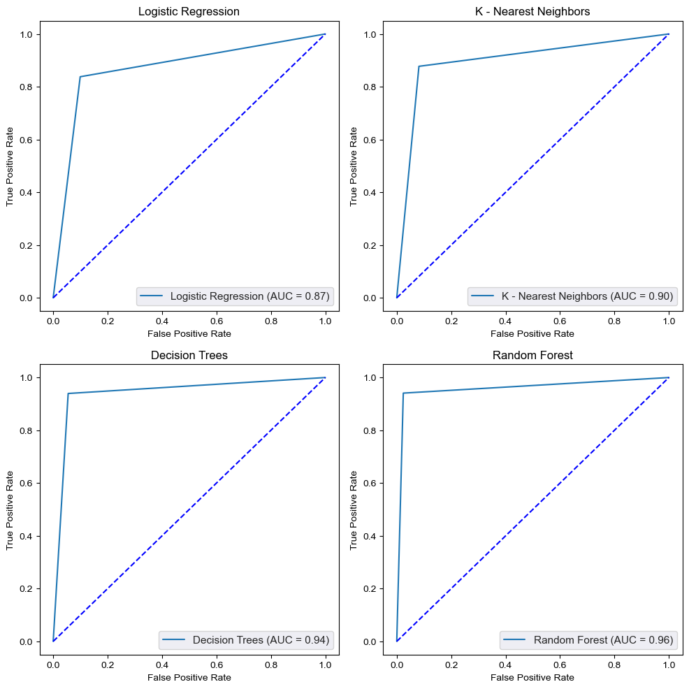

```python
from sklearn.metrics import roc_curve, roc_auc_score, RocCurveDisplay

fig, axes = plt.subplots(nrows=2, ncols=2, figsize=(10,10))
line = np.linspace(0,1)


sns.set(font_scale = 1.0)
for classifier, ax, name in zip(classifiers, axes.flatten(), classifiers_name):
    # Compute the false positive rate and true positive rate
    y_pred = classifier.predict(x_test)
    auc = roc_auc_score(y_test, y_pred)
    fpr, tpr, thresholds = roc_curve(y_test, y_pred)

    # Plot the ROC curve using RocCurveDisplay
    ax.plot(fpr, tpr)
    ax.plot(line, line, color = 'blue', linestyle = 'dashed')
    ax.title.set_text(name)
    ax.set_xlabel('False Positive Rate')
    ax.set_ylabel('True Positive Rate')
    ax.legend([f'{name} (AUC = {auc:.2f})'], loc = 'lower right')
fig.tight_layout(pad = 1.0);
```

It is clear that the best suited model to this occasion is the Random Forest with 0.96 of proportion of correct predictions over the total number of predictions.

Finnaly, let us try predicting one passenger overall satisfaction based in their rating.

### Satisfaction Prediction

```python
def satisfaction(rates):
    satisfaction = randomf.predict(rates)
    if (satisfaction == 0):
        print("Not Satisfied (0)")
    else:
        print("Satisfied (1)")
```

```python
rates = {'Departure Delay' : 20,
        'Departure and Arrival Time Convenience' : 0,
        'Ease of Online Booking' : 3,
        'Check-in Service' : 5,
        'Online Boarding' : 5,
        'Gate Location' : 2,
        'On-board Service' : 4,
        'Seat Comfort' : 3,
        'Leg Room Service' : 3,
        'Cleanliness' : 2,
        'Food and Drink ': 3,
        'In-flight Service' : 3,
        'In-flight Wifi Service' : 3,
        'In-flight Entertainment' : 2,
        'Baggage Handling' : 3,
        'Gender_Male' : 0,
        'Customer Type_Returning' : 0,
        'Type of Travel_Personal' : 1,
        'Class_Economy' : 1,
        'Class_Economy Plus' : 0 }
rates = np.array(list(rates.values())).reshape(1, -1)
satisfaction(rates)
```

```
Not Satisfied (0)
```